# Project Personalised Healthcare | SVM & Random Forest

June 2021

## BENCHMARK: COX REGRESSION

Preprocess the dataset

```r
# remove useless variables
gbcs2 = gbcs[,c(5:12,15:16)]

# fix data type
gbcs$grade = as.factor(gbcs$grade)
gbcs2$age = scale(gbcs2$age)
gbcs2$size = scale(gbcs2$size)
gbcs2$nodes = scale(gbcs2$nodes)
gbcs2$prog_recp = scale(gbcs2$prog_recp)
gbcs2$estrg_recp = scale(gbcs2$estrg_recp)

#  transform the menopause and hormone status into 0 and 1 variables
gbcs2$menopause = gbcs2$menopause-1
gbcs2$hormone = gbcs2$hormone-1

# create the dummies for the grade
grade123 = fastDummies::dummy_cols(gbcs2$grade)

# create the new matrix
gbcs1 = data.frame(gbcs2[,c(1:4, 6:10)], grade1 = grade123[,2], grade2 = grade123[,3], grade3 = grade123[,4])
```

Below, the final dataset

```r
head(gbcs1)
```

```
##          age menopause hormone        size        nodes  prog_recp  estrg_recp
## 1 -1.4872904         0       0 -0.79247861 -0.001863595  0.1532355  0.05714389
## 2 -0.1039922         0       0 -0.65258146 -0.732392712 -0.1581346 -0.53730113
## 3 -0.5980273         0       0  0.04690429 -0.732392712  1.5420451 -0.04737391
## 4 -1.2896764         0       0 -0.37278716 -0.367128153 -0.4200809 -0.55689822
## 5  1.0816919         1       1 -0.72253003 -0.732392712 -0.4497352 -0.56996295
## 6 -0.4004133         1       1  1.86556724 -0.367128153  1.2158478 -0.21068299
##   survtime censdead grade1 grade2 grade3
## 1     2282        0      0      0      1
## 2     2006        0      1      0      0
## 3     1456        1      0      1      0
## 4      148        0      1      0      0
## 5     1863        0      0      1      0
## 6     1933        0      1      0      0
```

Create the survival task

```r
task_gbcs = TaskSurv$new(id = "gbcs", backend = gbcs1, time = "survtime", event = "censdead")
```

Create the Cox Regression learner

```r
learner.cox = lrn("surv.coxph")
```

Perform 10-folds cross-validation

```r
set.seed(123)
cv10 = rsmp('cv',folds=10)

# pass the task, the learner and the resampling object
rr = resample(task_gbcs, learner.cox, cv10)
avg_cscore = rr$aggregate(msr("surv.cindex"))
```

Return the average model score *Harrell’s C-index*

```r
print(avg_cscore)
```

```
## surv.harrell_c
##      0.7392349
```

Plot the scores of the single trials

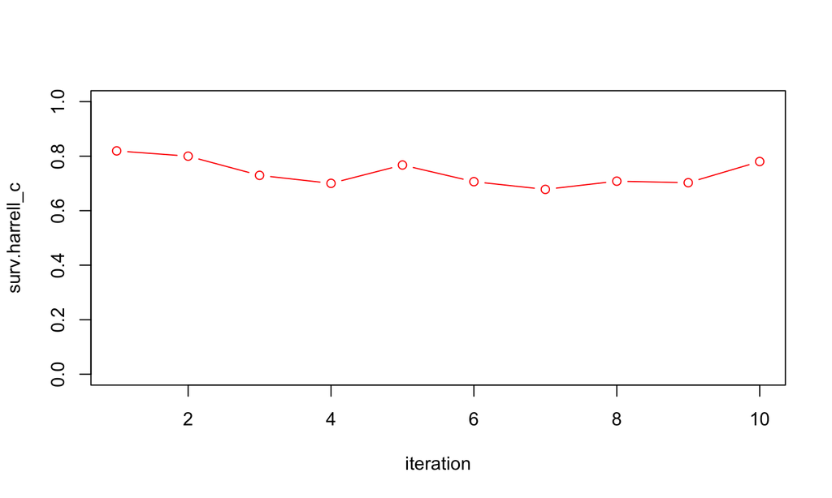

```r
scores = rr$score()
plot(scores[, c('iteration','surv.harrell_c')], type='b',ylim=c(0,1), xlim=c(1,10),col = c("red"))
```

## SUPPORT VECTOR MACHINES

#### SSVM: ALGORITHM FOR SURVIVAL SVM

- While the Cox model focuses on explicitly modelling the probabilistic mechanism of the phenomenon under study, the main focus of SVM is learning a predictive rule which will generalize well to the unseen data
- The algorithm for SSVM is based on the **concordance index**, which measures the association between predicted and observed failures in case of right censored data.
- It equals the ratio of concordant to comparable pairs of data points
- Two samples *i* and *j* are comparable if the survival time \(t_i\) of *i* is minor than the survival time of *j*: \((t_i<t_j)\) and the censoring variable \(\delta\) is equal to one. (\(\delta_i = 1\) if the event is observed, while \(\delta_i = 0\) in case of censoring)
- Two pair of samples *i* and *j* is concordant if they are comparable and the predicted health variable corresponding to the sample \(x_i\) is lower than the predicted heath variable corresponding to the sample \(x_j\)
- The sample-based concordance index of a model generating predictions \(u(x_i)\) for samples \(x_i\) from a dataset \(D={(x_i,t_i,δ_i)}\:\:i\:=1,…,N\) can be expressed as :

\[CI_N(u)=\frac{1}{(N(N-1))}\sum_{i≠j}I[\:(u(x_i)-u(x_j))\:(t(x_i)-t(x_j))\:]\]

### OPTIMAL HEALTH FUNCTION

- The learning strategy tries to find a mapping \(U: R^d→R\) which reconstructs the orders in the observed failure times measured by the corresponding \(CI_N\)
- Unfortunately, directly optimizing over \(CI_N\) is hard from the combinatorial point of view, so a convex relaxation written in terms of a hinge loss is proposed
- The optimal health function \(u(x_i)= ω^T φ(xi):R^d→R\) can be found as \((ω ̂,ζ ̂ ) =argmin\: ω,ζ\: \frac{1}{2}\: ω^T ω+C\sum_{i<j,δi=1} Vij\: ζij\), subject to \(ω^T φ= ω^T φ(xi)≥1-ζ_ij\) and \(ζ_ij≥0,\:∀i,j=1,…,N\) with \(C\) a positive real constant and \(V_{ij}=1\) if the pair \((x_i, x_j)\) is comparable, \(0\) otherwise
- \(φ: R^d ⟶ R^{dφ}\) is a feature map such that \(K(x,x')=φ(x)^T φ(x')\) is a positive definite kernel function \(K:R^d× R^d →R\)
- The major drawback of this algorithm is the large computational cost, which makes this method not applicable to large datasets

Create the Survival SVM learner

```r
learner.svm = suppressWarnings(mlr3::lrn("surv.svm"))
```

Show the learner possible parameters

```r
learner.svm$param_set$ids()
```

```
##  [1] "type"        "diff.meth"   "gamma.mu"    "opt.meth"    "kernel"
##  [6] "kernel.pars" "sgf.sv"      "sigf"        "maxiter"     "margin"
## [11] "bound"       "eig.tol"     "conv.tol"    "posd.tol"
```

The implementation ‘surv.svm’ provides 4 different **SVM models** adapted to perform survival analysis:

- *regression*: it includes regression constraints
- *vanbelle1*: it includes regression contraints
- *vanbelle2*: it is modelled as a ranking problem
- *hybrid*: it contains both regression and ranking constraints

The available **kernels** are:

- *lin_kernel*: linear kernel
- *add_kernel*: clinical kernel, developed for clinical use
- *rbf_kernel*: radial basis function kernel
- *poly_kernel*: polynomial kernel

Other parameters to be tuned are

- **gamma.mu**: regularisation parameters of SVM
- **diff.meth**: it builds the matrix of differences on comparable pairs

The dataset is divided into training and test set. The hyperparameters are tuned on the training set through a 5-folds cross validation, then the final score is assessed on the test set.

Create train and test set split

```r
set.seed(123)
train_set = sample(nrow(gbcs1), 0.8 * nrow(gbcs1))
test_set = setdiff(seq_len(nrow(gbcs1)), train_set)

train_gbcs1 = gbcs1[train_set, ]
test_gbcs1 = gbcs1[test_set, ]

print(dim(train_gbcs1))
```

```
## [1] 548  12
```

```r
print(dim(test_gbcs1))
```

```
## [1] 138  12
```

Create train and test tasks

```r
task_train_gbcs1 = TaskSurv$new(id = "gbcs", backend = train_gbcs1, time = "survtime", event = "censdead")
task_test_gbcs1 = TaskSurv$new(id = "gbcs", backend = test_gbcs1, time = "survtime", event = "censdead")
```

Unfortunately, not all models work. This is due to:

- **Errors during the optimisation**
- **Implementation problems for the hybrid SVM model**: the parameter ‘gamma.mu’ requires a vector of 2 values for this model, however when defining the parameters we must indicate a minimum and a maximum value for float parameters. Hence, an error is raised when the model is optimised saying that the parameter ‘gamma.mu’ must be a vector of two numeric values.

The only models which work are:

1. Regression with linear kernel
2. Regression with rbf kernel
3. Regression with clinical kernel

For all of them the ‘iprop’ optimiser is used. There is no need to use the parameter *diff.meth*

Define the 3 models

```r
learner.svm.regression.1 = suppressWarnings(mlr3::lrn("surv.svm", gamma.mu=0.01, type='regression',
                                                      kernel='lin_kernel'))
learner.svm.regression.2 = suppressWarnings(mlr3::lrn("surv.svm", gamma.mu=0.01, type='regression',
                                                      kernel='rbf_kernel'))
learner.svm.regression.3 = suppressWarnings(mlr3::lrn("surv.svm", gamma.mu=0.01, type='regression',
                                                      kernel='add_kernel'))
```

Define the searching space

```r
searchspace.svm.regression = ParamSet$new(list(
  ParamDbl$new('gamma.mu', 0.01, 2),
  ParamFct$new('opt.meth', 'ipop')
))
```

Create a summary table to store the optimised hyperparameters and the score of all the different SVM regression models

```r
models_results.svm = data.frame(
  'model_name'=rep(NA,3), 'kernel'=rep(NA,3), 'opt.meth'=rep(NA,3),
  'gamma.mu'=rep(NA,3), 'test_c_harrell'=rep(NA,3))
```

Tune the hyperparameters for each model and then compute the score of the best model on the test set.

```r
set.seed(124)
c=1

for(learner in c(learner.svm.regression.1, learner.svm.regression.2, learner.svm.regression.3)) {
instance = TuningInstanceSingleCrit$new(
  task_train_gbcs1, learner, rsmp('cv',folds=5), msr('surv.cindex'), trm("evals", n_evals = 5),
  searchspace.svm.regression #Searching Space
  )

  # perform a random search to optimise the hyper parameters
  rsearch = tnr('random_search') #Tuner
  rsearch$optimize(instance)
  models_results.svm$gamma.mu[c]=instance$result_learner_param_vals$gamma.mu
  models_results.svm$model_name[c]=instance$result_learner_param_vals$type
  models_results.svm$kernel[c]=instance$result_learner_param_vals$kernel
  models_results.svm$opt.meth[c]=instance$result_learner_param_vals$opt.meth
  # train the model on the training set by using the optimised hyper parameters
  learner$param_set$values = instance$result_learner_param_vals
  learner$train(task_train_gbcs1)
  # make predictions on the test set
  prediction.svm = learner$predict(task_test_gbcs1)
  models_results.svm$test_c_harrell[c] = prediction.svm$score(msr('surv.cindex'))

  c=c+1
}
```

Scores *Harrell’s C-index* of the regression SVM models

```r
models_results.svm
```

```
##   model_name     kernel opt.meth  gamma.mu test_c_harrell
## 1 regression lin_kernel     ipop 1.4444467      0.6562412
## 2 regression rbf_kernel     ipop 1.0045101      0.6132714
## 3 regression add_kernel     ipop 0.9191204      0.6435615
```

## RANDOM FOREST

- A random forest is a nonparametric machine learning strategy that can be used for building a risk prediction model in survival analysis.
- In RF, randomization is introduced in two forms. First, a randomly drawn bootstrap sample of the data is used to grow a tree. Second, at each node of the tree, a randomly selected subset of variables (covariates) is chosen as candidate variables for splitting.
- Averaging over trees, in combination with the randomization used in growing a tree, enables RF to approximate rich classes of functions while maintaining low generalization error
- Considerable empirical evidence has shown RF to be highly accurate

#### RANDOM SURVIVAL FOREST (randomSurvivalForest)

- In random survival forests *(Ishwaran et al. 2008)*, the ensemble is constructed by aggregating tree-based Nelson-Aalen estimators
- In each terminal node of a tree, the conditional cumulative hazard function \(\widehat{H_b} (t│x)\) is estimated using the Nelson-Aalen using the “in-bag” data \[ \widehat{H_b} (t│x)=∫_0^t\frac{\tilde{N_b^*}(ds,x)}{\widetilde{Y_b^* (s,x)}}\] where \(\tilde{N_b}^*(s, x)\) counts the uncensored events until time \(s\) and \(\tilde{Y_b}^*(s, x)\) is the number at risk at time \(s\).
- The ensemble survival function from random survival forest is \[\hat{S}^{rsf}(t│x)=exp(-\frac{1}{B} ∑_{b=1}^{B}\widehat{H_b}(t│x)\]

Preprocess the dataset. In the case of random forest no dummy variables are needed

```r
# remove useless variables
gbcs2 = gbcs[,c(5:12,15:16)]

# fix data type
gbcs$grade = as.factor(gbcs$grade)
gbcs2$age = scale(gbcs2$age)
gbcs2$size = scale(gbcs2$size)
gbcs2$nodes = scale(gbcs2$nodes)
gbcs2$prog_recp = scale(gbcs2$prog_recp)
gbcs2$estrg_recp = scale(gbcs2$estrg_recp)

# we transform the menopause and hormone status into 0 and 1 variables
gbcs2$menopause = gbcs2$menopause-1
gbcs2$hormone = gbcs2$hormone-1
```

Below, the final dataset

```r
head(gbcs2)
```

```
##          age menopause hormone        size grade        nodes  prog_recp
## 1 -1.4872904         0       0 -0.79247861     3 -0.001863595  0.1532355
## 2 -0.1039922         0       0 -0.65258146     1 -0.732392712 -0.1581346
## 3 -0.5980273         0       0  0.04690429     2 -0.732392712  1.5420451
## 4 -1.2896764         0       0 -0.37278716     1 -0.367128153 -0.4200809
## 5  1.0816919         1       1 -0.72253003     2 -0.732392712 -0.4497352
## 6 -0.4004133         1       1  1.86556724     1 -0.367128153  1.2158478
##    estrg_recp survtime censdead
## 1  0.05714389     2282        0
## 2 -0.53730113     2006        0
## 3 -0.04737391     1456        1
## 4 -0.55689822      148        0
## 5 -0.56996295     1863        0
## 6 -0.21068299     1933        0
```

Create the Random Forest learner using the implementation ‘surv.ranger’

```r
learner.rf = suppressWarnings(mlr3::lrn("surv.ranger"))
```

Show the possible parameters

```r
learner.rf$param_set$ids()
```

```
##  [1] "num.trees"                    "mtry"
##  [3] "importance"                   "write.forest"
##  [5] "min.node.size"                "replace"
##  [7] "sample.fraction"              "splitrule"
##  [9] "num.random.splits"            "max.depth"
## [11] "alpha"                        "minprop"
## [13] "regularization.factor"        "regularization.usedepth"
## [15] "seed"                         "split.select.weights"
## [17] "always.split.variables"       "respect.unordered.factors"
## [19] "scale.permutation.importance" "keep.inbag"
## [21] "holdout"                      "num.threads"
## [23] "save.memory"                  "verbose"
## [25] "oob.error"
```

The parameters to be tuned are:

- **mad.depth**: depth of the single trees
- **num.trees**: total number of trees to use
- **min.node.size**: minimal number of observations per node
- **mtry**: number of variables randomly selected to be used at each split
- **splitrule**: splitting rule

2 alternative methods are used:

1. **Training and test set split**: optimise the hyper parameters with a 5-folds cross-validation on the training set and then test the best model on the test set
2. **Nested cross validation**: optimise the hyper parameters with an inner 5-folds cross-validation. Assess the final score with an outer 5 folds cross validation. According to the documentation of *mlr3* website, the outer cross validation is performed by only using the held out set, not on the set used for the training. Hence, the problem of over optimistic performances should be reduced.

#### 1. TRAIN AND TEST SET SPLIT

Perform a 5-folds cross-validation on the training set, then retrieve the score on the test set. Split the train and test set

```r
set.seed(123)
train_set = sample(nrow(gbcs2), 0.8 * nrow(gbcs2))
test_set = setdiff(seq_len(nrow(gbcs2)), train_set)

train_gbcs = gbcs2[train_set, ]
test_gbcs = gbcs2[test_set, ]

print(dim(train_gbcs))
```

```
## [1] 548  10
```

```r
print(dim(test_gbcs))
```

```
## [1] 138  10
```

Create the train and test tasks

```r
task_train_gbcs2 = TaskSurv$new(id = "gbcs", backend = train_gbcs, time = "survtime", event = "censdead")
task_test_gbcs2 = TaskSurv$new(id = "gbcs", backend = test_gbcs, time = "survtime", event = "censdead")
```

Create the searching space

```r
searchspace.rf = ParamSet$new(list(
  ParamInt$new('max.depth', 1, 100),
  ParamInt$new('num.trees', 500, 1000),
  ParamInt$new('min.node.size', 5, 30),
  ParamInt$new('mtry', 1, 8),
  ParamFct$new('splitrule',c("logrank", "extratrees", "C","maxstat"))
))
```

Create the instance object of hyperparameters tuning

```r
instance = TuningInstanceSingleCrit$new(
  task_train_gbcs2, #Task
  learner.rf, #Learner
  rsmp('cv',folds=5), #Resampling
  msr('surv.cindex'), #Measure
  trm("evals", n_evals = 5), #Terminator
  searchspace.rf #Searching space
  )
```

Perform a random search for optimising the hyper parameters

```r
set.seed(123)
rsearch = tnr('random_search') #Tuner
rsearch$optimize(instance)
```

Hyperparameters values of the best model

```r
instance$result_learner_param_vals
```

```
## $num.threads
## [1] 1
##
## $max.depth
## [1] 70
##
## $num.trees
## [1] 820
##
## $min.node.size
## [1] 30
##
## $mtry
## [1] 6
##
## $splitrule
## [1] "C"
```

Train the best model on the training set

```r
set.seed(123)
learner.rf$param_set$values = instance$result_learner_param_vals
learner.rf$train(task_train_gbcs2)
```

Make predictions on the test set and retrieve the score *Harrell’s C-index*

```r
set.seed(123)
prediction.rf = learner.rf$predict(task_test_gbcs2)
prediction.rf$score(msr('surv.cindex'))
```

```
## surv.harrell_c
##      0.7193576
```

#### 2. NESTED CROSS VALIDATION

Below, an image taken from the *mlr3* documentation

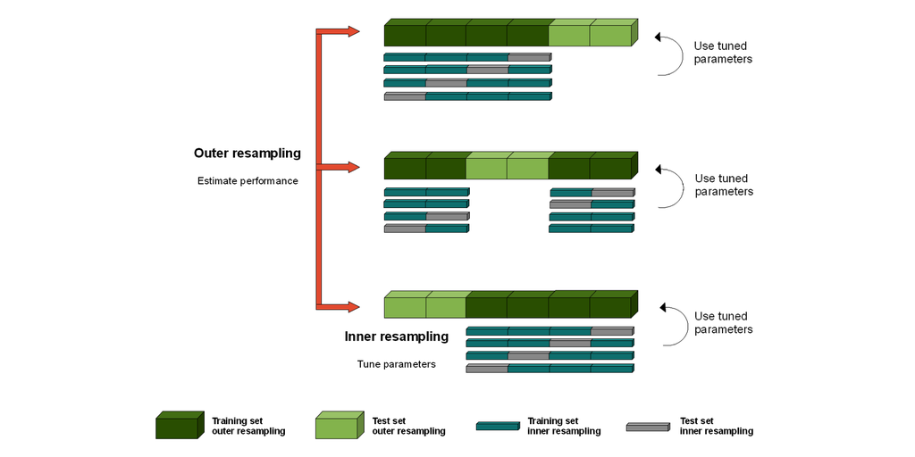

Create the task

```r
task_gbcs2 = TaskSurv$new(id = "gbcs", backend = gbcs2, time = "survtime", event = "censdead")
```

Create the setting for hyperparameters tuning

```r
optlrnrf = AutoTuner$new(
  learner.rf, #Learner
  rsmp('cv',folds=5), #Resampling
  msr('surv.cindex'), #Measure
  trm("evals", n_evals = 5), #Terminator
  tnr('random_search'), #Tuner
  searchspace.rf #Searching space
  )
```

Perform the 5-folds nested cross-validation

```r
set.seed(123)
rr = resample(task_gbcs2, optlrnrf, rsmp('cv',folds=5), store_models=TRUE)
```

Show the average score *Harrell’s C-index*

```r
avg_cscore_rf= rr$aggregate(msr("surv.cindex"))
print(avg_cscore_rf)
```

```
## surv.harrell_c
##      0.7376484
```

Plot the scores of the single trials

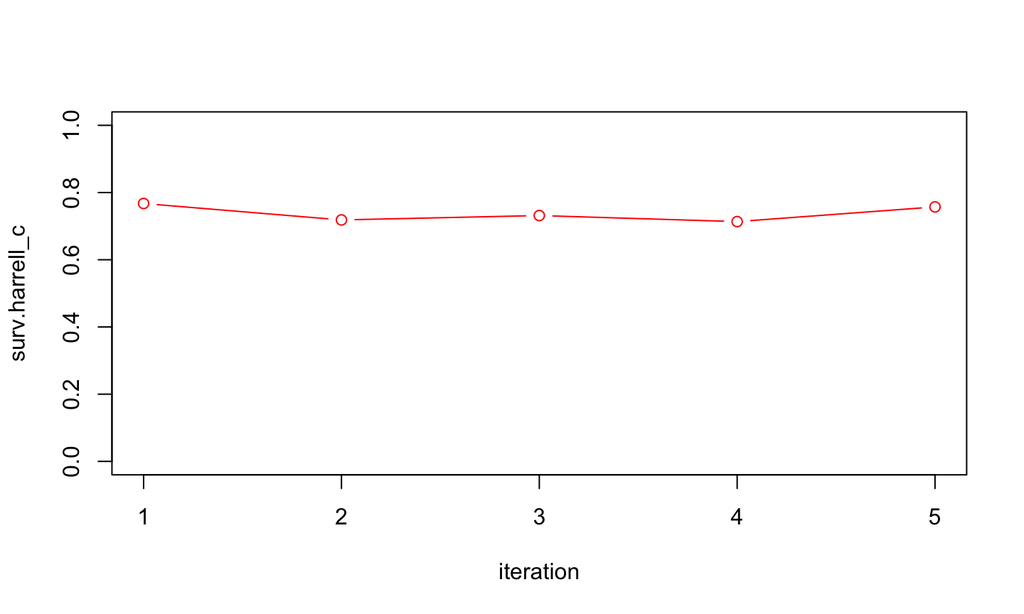

```r
scores = rr$score()
plot(scores[, c('iteration','surv.harrell_c')], type='b',ylim=c(0,1), xlim=c(1,5),col = c("red"))
```

### CONCLUSIONS

- Performance of the BENCHMARK MODEL: \(0.739\)
- Best performance of the SURVIVAL SVM MODEL: \(0.656\)
- Best performance of the RANDOM FOREST MODEL: \(0.738\)

The SVM model performed significantly worse than the Cox Regression with a performance about 10% lower. On the other hand, the Survival Random Forest model obtained nearly the same performance by using an inner 5-folds cross-validation followed by an outer 5-folds cross-validation.